# Project: Analysis of Start-up Success

Amit Peled

2024-03-12

## Read In Data

```r
data <- read.csv("cleaned_investments_VC.csv")
head(data)
```

```
##                 name              market funding_total_usd    status
## 1           #waywire                News           1750000  acquired
## 2  'Rock' Your Paper          Publishing             40000 operating
## 3  (In)Touch Network         Electronics           1500000 operating
## 4 -R- Ranch and Mine             Tourism             60000 operating
## 5        1,2,3 Listo          E-Commerce             40000 operating
## 6      1-800-DOCTORS Health and Wellness           1750000 operating
##          region       city funding_rounds founded_at founded_month
## 1 New York City   New York              1 2012-06-01       2012-06
## 2       Tallinn    Tallinn              1 2012-10-26       2012-10
## 3        London     London              1 2011-04-01       2011-04
## 4        Dallas Fort Worth              2 2014-01-01       2014-01
## 5      Santiago Las Condes              1 2012-01-01       2012-01
## 6        Newark     Iselin              1 1984-01-01       1984-01
##   founded_quarter founded_year first_funding_at last_funding_at    seed venture
```

[output cut: 34 more lines]

```r
colnames(data)
```

```
##  [1] "name"                   "market"                 "funding_total_usd"
##  [4] "status"                 "region"                 "city"
##  [7] "funding_rounds"         "founded_at"             "founded_month"
## [10] "founded_quarter"        "founded_year"           "first_funding_at"
## [13] "last_funding_at"        "seed"                   "venture"
## [16] "equity_crowdfunding"    "undisclosed"            "convertible_note"
## [19] "debt_financing"         "angel"                  "grant"
## [22] "private_equity"         "post_ipo_equity"        "post_ipo_debt"
## [25] "secondary_market"       "product_crowdfunding"   "round_A"
## [28] "round_B"                "round_C"                "round_D"
## [31] "round_E"                "round_F"                "round_G"
## [34] "round_H"                "country"                "age"
## [37] "success_metric_updated"
```

## Data Manipualtion for Tests/Variables of Interest

```r
funding_types <- c('seed', 'venture', 'equity_crowdfunding', 'undisclosed', 'convertible_note',
                   'debt_financing', 'angel', 'grant', 'private_equity', 'post_ipo_equity',
                   'post_ipo_debt', 'secondary_market', 'product_crowdfunding')

# Convert funding columns to numeric, ensuring NAs are turned into 0
data_with_method_of_funding <- data %>%
  mutate(across(all_of(funding_types), ~ifelse(is.na(.), 0, as.numeric(.))))

# Function to determine the primary funding type
determine_primary_funding <- function(row) {
  funding_values <- as.numeric(row[names(row) %in% funding_types])
  if (sum(funding_values) == 0) {
    return('None')
  } else {
    return(names(row)[which.max(funding_values)])
  }
}

data_with_method_of_funding$primary_funding_type <- apply(data_with_method_of_funding[, funding_types], 1, determine_primary_funding)

data_with_method_of_funding$success_metric_updated <- ifelse(
  data_with_method_of_funding$success_metric_updated == "Potentially Successful",
  "Unsuccessful",
  data_with_method_of_funding$success_metric_updated
)

head(data_with_method_of_funding)
```

```
##                 name              market funding_total_usd    status
## 1           #waywire                News           1750000  acquired
## 2  'Rock' Your Paper          Publishing             40000 operating
## 3  (In)Touch Network         Electronics           1500000 operating
## 4 -R- Ranch and Mine             Tourism             60000 operating
## 5        1,2,3 Listo          E-Commerce             40000 operating
## 6      1-800-DOCTORS Health and Wellness           1750000 operating
##          region       city funding_rounds founded_at founded_month
## 1 New York City   New York              1 2012-06-01       2012-06
## 2       Tallinn    Tallinn              1 2012-10-26       2012-10
## 3        London     London              1 2011-04-01       2011-04
## 4        Dallas Fort Worth              2 2014-01-01       2014-01
## 5      Santiago Las Condes              1 2012-01-01       2012-01
## 6        Newark     Iselin              1 1984-01-01       1984-01
##   founded_quarter founded_year first_funding_at last_funding_at    seed venture
```

[output cut: 34 more lines]

## Exploratory Data Analysis

### Distribution of Startup Success Categories

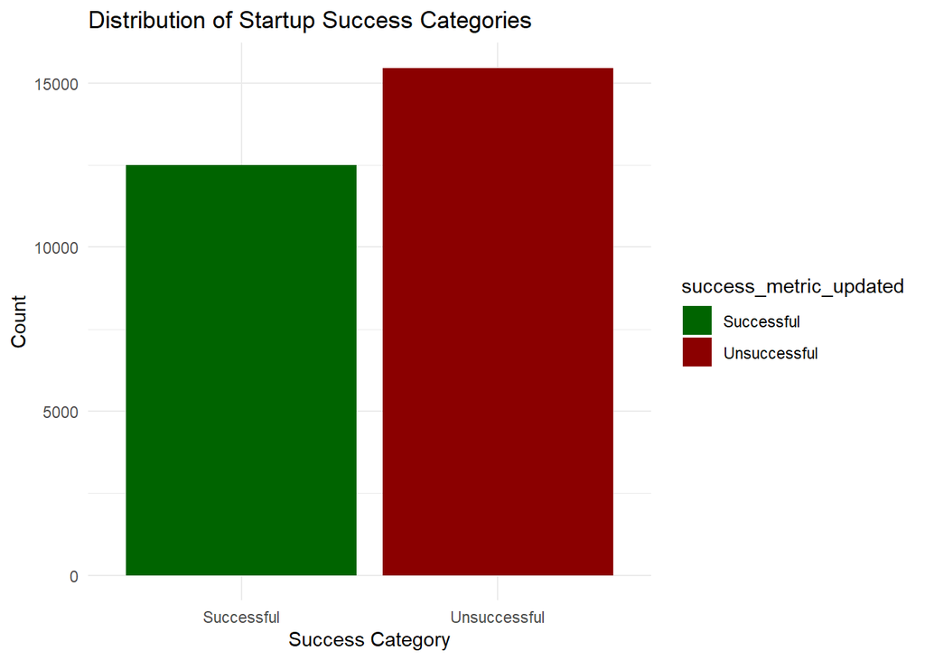

```r
ggplot(data_with_method_of_funding, aes(x = success_metric_updated, fill = success_metric_updated)) +
  geom_bar() +
  scale_fill_manual(values=c("Successful"="darkgreen", "Unsuccessful"="darkred")) +
  theme_minimal() +
  labs(title = "Distribution of Startup Success Categories", x = "Success Category", y = "Count")
```

### Percentage of Startups by Success Category and Primary Funding Type

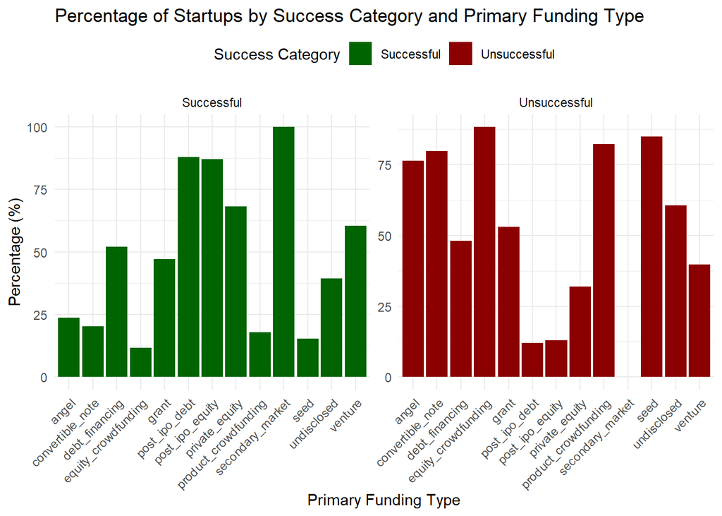

```r
data_with_method_of_funding %>%
  group_by(primary_funding_type, success_metric_updated) %>%
  summarize(count=n()) %>%
  mutate(percentage = count / sum(count) * 100) %>%
  ggplot(aes(x=primary_funding_type, y=percentage, fill=success_metric_updated)) +
  geom_bar(stat="identity", position="dodge") +
  scale_fill_manual(values=c("Successful"="darkgreen", "Unsuccessful"="darkred")) +
  facet_wrap(~success_metric_updated, scales="free_y") +
  labs(title="Percentage of Startups by Success Category and Primary Funding Type", x="Primary Funding Type", y="Percentage (%)", fill="Success Category") +
  theme_minimal() +
  theme(axis.text.x=element_text(angle=45, hjust=1), legend.position="top")
```

### Distribution of Total Funding by Funding Type and Success Category

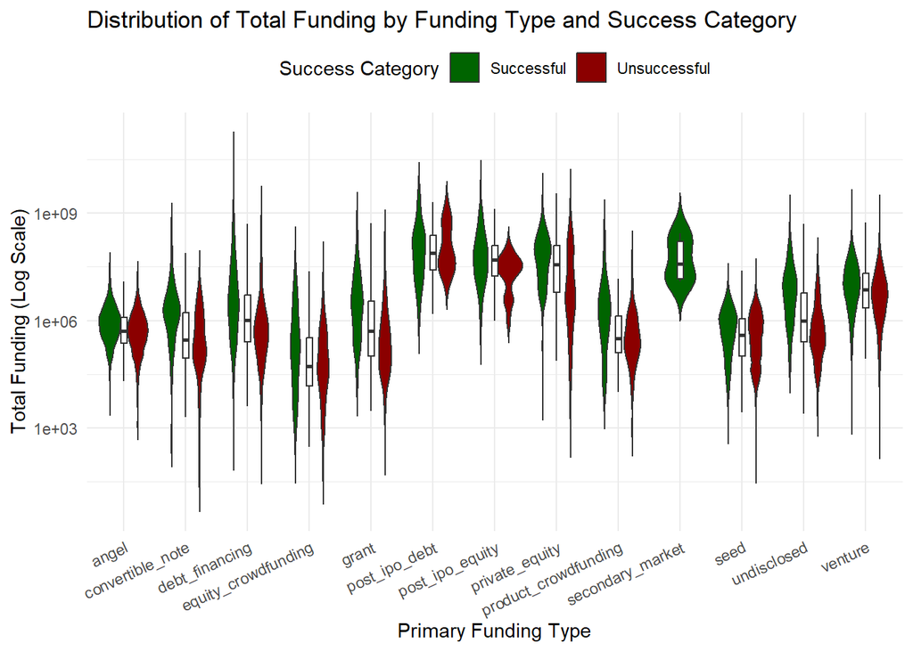

```r
data_with_method_of_funding$total_funding <- rowSums(data_with_method_of_funding[, funding_types])

ggplot(data_with_method_of_funding, aes(x=primary_funding_type, y=total_funding, fill=success_metric_updated)) +
  geom_violin(trim=FALSE) +
  geom_boxplot(width=0.1, fill="white", outlier.shape=NA) +
  scale_fill_manual(values=c("Successful"="darkgreen", "Unsuccessful"="darkred")) +
  scale_y_continuous(trans='log10') +
  labs(title="Distribution of Total Funding by Funding Type and Success Category",
       x="Primary Funding Type",
       y="Total Funding (Log Scale)",
       fill="Success Category") +
  theme_minimal() +
  theme(axis.text.x=element_text(angle=25, hjust=1),
        legend.position="top")
```

### Correlation of Total Funding Amounts with Startup Success

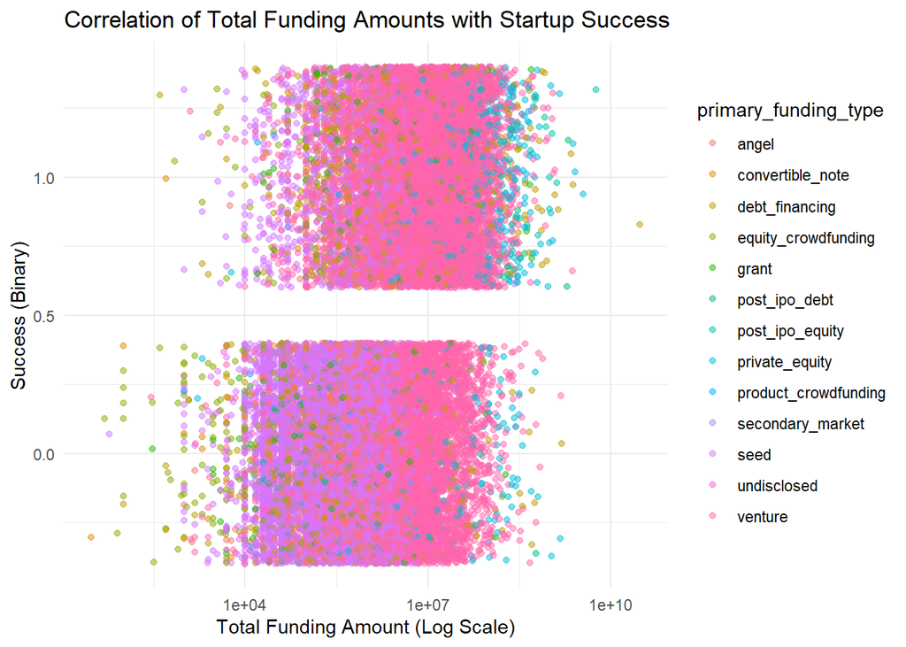

```r
data_with_method_of_funding %>%
  mutate(total_funding=rowSums(select(., all_of(funding_types))),
         success_binary=ifelse(success_metric_updated=="Successful", 1, 0)) %>%
  ggplot(aes(x=total_funding, y=success_binary, color=primary_funding_type)) +
  geom_jitter(alpha=0.5) +
  scale_x_log10() +
  labs(title="Correlation of Total Funding Amounts with Startup Success", x="Total Funding Amount (Log Scale)", y="Success (Binary)") +
  theme_minimal() +
  theme(legend.position="right")
```

## Statistical Analysis Approaches

### Chi-Square Test of Independence

The Chi-Square Test was applied to determine whether a statistically significant relationship exists between the categorical variables: the type of funding and start up success rate.

$H_0$ - There is no association between the type of funding and the success rate of start ups.

$H_a$ - There is a significant association between the type of funding a start up receives and the success rate of start ups.

The dataset categorizes start ups as either successful or unsuccessful, pooling those labeled “potentially successful” into the unsuccessful group. This test was chosen for its ability to evaluate the association between categorical variables in a contingency table format.

To implement this analysis, one would construct a contingency table summarizing the frequencies of observed successes and failures across various funding types. The test compares the observed frequencies against the expected frequencies, which are calculated under the assumption that the variables are independent. For the Chi-Square Test to be valid, an important assumption is that the expected frequencies in each cell of the contingency table should be greater than 5. This ensures that the test has enough power to detect an association if one exists.

A significant Chi-Square statistic may suggest that the type of funding does, in fact, influence a start up success rate, indicating that certain funding types are associated with higher or lower success rates. This may guide investors and entrepreneurs in making informed decisions about the funding strategies they want to pursue for their endeavors.

```r
# Filter for Chi-Square Test to include only “successful” and “unsuccessful” start ups
data_chi_square <- data_with_method_of_funding %>%
  filter(success_metric_updated %in% c("Successful", "Unsuccessful"))

# Create contingency table
contingency_table <- table(data_chi_square$primary_funding_type, data_chi_square$success_metric_updated)
print(contingency_table)
```

```
##
##                        Successful Unsuccessful
##   angel                       375         1212
##   convertible_note             43          169
##   debt_financing              649          598
##   equity_crowdfunding          46          346
##   grant                       194          218
##   post_ipo_debt                22            3
##   post_ipo_equity             107           16
##   private_equity              487          228
##   product_crowdfunding         18           83
##   secondary_market              6            0
##   seed                       1131         6286
##   undisclosed                 123          189
##   venture                    9305         6116
```

```r
# Chi-Square Test
chi_square_result <- chisq.test(contingency_table)
print(chi_square_result)
```

```
##
##  Pearson's Chi-squared test
##
## data:  contingency_table
## X-squared = 4971.9, df = 12, p-value < 2.2e-16
```

The Chi-Square test returned a test statistic of 4971.9 with 12 degrees of freedom and a p-value less than 2.2e-16, leading us to reject the null hypothesis at the 0.05 significance level. This outcome suggests a significant association between the type of funding and the success rate of start ups.

[figure not shown]

```r
table <- as.matrix(table(data_chi_square$success_metric_updated, data_chi_square$primary_funding_type))

# Convert the table to proportions
table_prop <- prop.table(table, margin = 2) # Normalize by columns to get proportions

# Melt the table for use with ggplot
melted_table <- melt(table_prop)

# Create the heatmap
ggplot(melted_table, aes(x=Var1, y=Var2, fill=value)) +
  geom_tile(color = "white") +
  scale_fill_gradient(low = "orange", high = "darkblue", name = "Proportion") +
  theme_classic() +
  theme(axis.text.x = element_text(hjust = 1),
        axis.title = element_text(size = 12, face = "bold"),
        legend.position = "right") +
  labs(title = "Normalized Heatmap of Startup Success by Funding Type",
       subtitle = "Proportions within each funding type are shown",
       x = "Funding Type",
       y = "Success Category",
       fill = "Proportion")
```

### Logistic Regression Analysis

Logistic Regression was utilized to model the probability of startup success as a function of funding type. As the success metric is binary in our dataset, this method is appropriate for estimating the odds ratios of success across different funding types.

To implement this analysis, the categorical variable indicating the type of funding would be transformed into a series of dummy variables, allowing for them to be used as predictors in the regression model. The dependent variable, startup success, would also be coded in binary terms. The logistic regression model is then defined and fitted to the dataset, allowing the estimation of success probabilities conditional on funding types.

Interpreting the coefficients from the model would provide a quantitative measure of the association between funding type and success odds. This method offers an in-depth perspective of how different types of funding might affect the chances of a startup’s success beyond the potentially discovered existence of an association indicated by the Chi-Square Test.

```r
funding_dummies <- model.matrix(~ primary_funding_type - 1, data=data_with_method_of_funding)
data_with_method_of_funding <- cbind(data_with_method_of_funding, funding_dummies)

# Fit the logistic regression model
model_log <- multinom(success_metric_updated ~ funding_dummies, data=data_with_method_of_funding)
tidy_model <- tidy(model_log) %>%
  mutate(term = gsub("funding_dummies", "", term))

# standard errors and CIs from the model
tidy_model <- tidy_model %>%
  mutate(
    std.error = abs(estimate) / qnorm(0.975),  # Assuming a z-dist for the standard error
    conf.low = estimate - (1.96 * std.error),
    conf.high = estimate + (1.96 * std.error)
  )
tidy_model$term <- gsub("primary_funding_type", "", tidy_model$term)
print((tidy_model %>% select(-y.level)))
```

```
## # A tibble: 14 × 7
##    term                 estimate std.error  statistic   p.value conf.low conf.…¹
##    <chr>                   <dbl>     <dbl>      <dbl>     <dbl>    <dbl>   <dbl>
##  1 (Intercept)            -0.569    0.290     -9.48e0 2.65e- 21 -1.14e+0 1.05e-5
##  2 angel                   1.74     0.889      2.15e1 1.33e-102 -3.20e-5 3.48e+0
##  3 convertible_note        1.94     0.989      1.15e1 1.04e- 30 -3.56e-5 3.88e+0
##  4 debt_financing          0.487    0.249      6.13e0 8.99e- 10 -8.95e-6 9.75e-1
##  5 equity_crowdfunding     2.59     1.32       1.65e1 1.74e- 61 -4.75e-5 5.17e+0
##  6 grant                   0.686    0.350      6.30e0 2.99e- 10 -1.26e-5 1.37e+0
##  7 post_ipo_debt          -1.42     0.726     -2.50e0 1.24e-  2 -2.85e+0 2.62e-5
##  8 post_ipo_equity        -1.33     0.679     -5.25e0 1.56e-  7 -2.66e+0 2.45e-5
##  9 private_equity         -0.190    0.0968    -1.99e0 4.61e-  2 -3.80e-1 3.49e-6
## 10 product_crowdfunding    2.10     1.07       8.51e0 1.80e- 17 -3.85e-5 4.20e+0
## 11 secondary_market      -10.6      5.41      -7.92e6 0         -2.12e+1 1.95e-4
## 12 seed                    2.28     1.17       3.41e1 1.03e-254 -4.20e-5 4.57e+0
## 13 undisclosed             0.999    0.510      8.16e0 3.24e- 16 -1.84e-5 2.00e+0
## 14 venture                 0.149    0.0763     2.41e0 1.58e-  2 -2.75e-6 2.99e-1
## # … with abbreviated variable name ¹conf.high
```

Following the logistic regression analysis, the model allowed for the extraction of probability predictions for each startup success category based on the funding type. All predictors in the model were found to be statistically significant, with the highest p-value for any term being 0.0461.

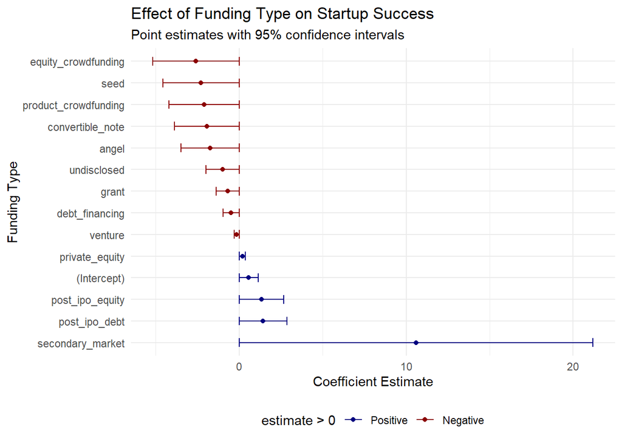

```r
# point estimates with CIs
ggplot(tidy_model, aes(x=reorder(term, estimate), y=-estimate, color=estimate > 0)) +
  geom_point() +
  geom_errorbar(aes(ymin=-conf.low, ymax=-conf.high), width=0.4) +
  coord_flip() +
  scale_color_manual(values = c("navy", "darkred"), labels = c("Positive", "Negative")) +
  labs(title = "Effect of Funding Type on Startup Success",
       subtitle = "Point estimates with 95% confidence intervals",
       y = "Coefficient Estimate",
       x = "Funding Type") +
  theme_minimal() +
  theme(legend.position = "bottom")
```

The results from the logistic regression are visually presented in Figure 3.4.3, where the point estimates with their corresponding 95% confidence intervals indicate the influence of different funding types on startup success. Types of funding that are plotted to the right of the zero line (colored in blue) exercise a positive influence, implying that, when other factors are held constant, they are associated with increased odds of startup success. On the contrary, funding types situated to the left of the zero line (colored in red), such as `product_crowdfunding` and `equity_crowdfunding`, exhibit a negative relationship with the likelihood of startup success.